# Political Violence in the Urban Space: Evidence from the GTD

Lukas Bretzinger, Cameron Reed, Sascha Schuster

Fall 2014

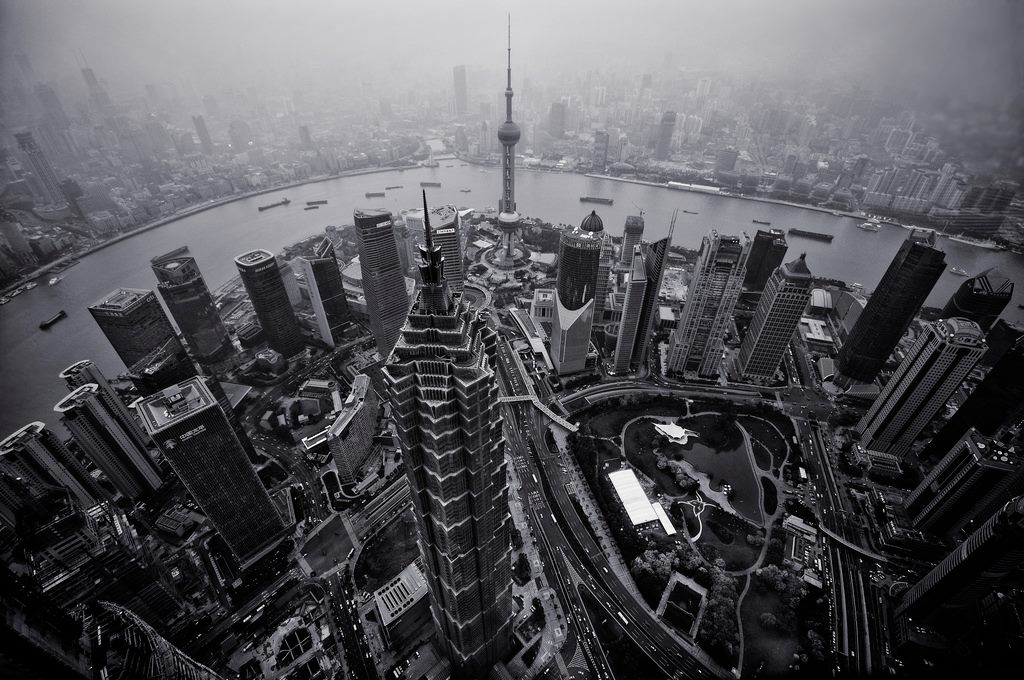

*This, then, is the suite of problems – framed by the megatrends of population growth, urbanization, littoralization, and connectedness – that will define the environment for future conflict, and for every aspect of life, in the next generation.*

*–David Kilcullen*

## Intro

The world is in flames. Political violence is a concern to us all. Why does it occur? How to respond? David Kilcullen, an influential counterinsurgency expert published his new book called *Out of the Mountains. The Coming Age of the Urban Guerilla* (Kilcullen 2013). He describes political violence as something that used to occur “out there”, far from big cities and urban life. He claims to see a change. In the future, this political violence will come out of the mountains to appear in big cities that are highly connected with each other, crowded and often close to the coastline. These places will become the space of future conflict. That raises questions of life and death:

*Where does political violence happen?*

*Is it moving to the urban, connected, crowded, littoral space?*

We know that people historically have always preferred to live at the coast, and that there is a global urbanization - people moving to the cities rather than living in villages. But Kilcullen goes further. He suggests that political violence is migrating towards the urban, crowded, connected, and littoral space faster than people are. We wanted to find out whether that may be true. Have a look at our map. What you see are bubbles that stand for cities in the Middle East: The size stands for the number of inhabitants, the color for the victims of terrorist from 1990-2003. You can use your cursor to get more information.

[interactive chart not shown]

What you see is the result of week-long work with different data sets. And now the same for 2004 until the end of our data set in 2013. Baghdad changed our color scale with almost ten times more accumulated victims than any other city the 14 years before the war. Many would argue that this was to be expected as the Iraq War changed the whole region dramatically. But there are other changes everywhere, have a look at Yemen and the Stans. This is just a vivid example of the shifting geography of political violence.

[interactive chart not shown]

## Measures

We conduct a statistical analysis to see if over the past years, acts of political violence were in fact more likely to happen in urban and littoral environments, or it is just that people are moving to these spaces. For this, we gather data from a lot of different sources. Our main data set is the Global Terrorism Database, a huge data set that contains over 120,000 violent attacks since 1970 (START 2013). Additionally, we want to know a lot about the environment in which these attacks take place. This information is not included in the GTD. Some other data comes from the World Bank, some from NASA, some even from Wikipedia, but all our source combined include:

- Global night light emanations captured by satellites and equality of distribution among population
- Distance of every place in the world to the coastline
- Travel distance to the next bigger city
- The type of land cover (forest? buildings?)
- Population density
- Economic activity
- City population
- And the change over time for all of these

If you have ever worked with data yourself, you probably know that most of the time you spend finding, gathering, organizing, cleaning, tidying, calculating, merging. All of our data sets have a lot of missing information and we needed a lot of work to align things like city and country names and find all the missing values of information. The goal is to pin all 120,000 incidences down on a map so we can investigate their environment. For around 80,000 it’s done successfully. Given that all we know about many is not much better than “Highway between Delhi and Agra”, that is good for the moment.

## Empirics

We have taken a couple of attacks from the GTD that took place in Turkey just to show what we are doing. Here is a little description of each of them and what happened there:

- 2003-11-14, Istanbul: Two car bombings by the militant Islamic group, Great East Islamic Raiders Front (IBDA-C - Islami Buyuk Dogu Akincilar Cephesi), on synagogues in Istanbul, Turkey, killed at least twenty people and injured 302 others. One of the two almost simultaneous blasts occurred at the Beth Israel Synagogue, damaging the building and several cars. Numerous people were reportedly killed and injured in the bombing. The group identified itself in a telephone call to the Anadolu News Agency.
- 2003-11-14, Istanbul: Two car bombings by the militant Islamic group, Great East Islamic Raiders Front (IBDA-C - Islami Buyuk Dogu Akincilar Cephesi), on synagogues in Istanbul, Turkey, killed at least twenty people and injured 302 others. One of the two almost simultaneous blasts occurred at the Beth Israel Synagogue, damaging the building and several cars. Numerous people were reportedly killed and injured in the bombing. The group identified itself in a telephone call to the Anadolu News Agency.
- 1999-07-30, Gurpinar: A total of four village guards were killed in Gurpinar, Turkey, when a group of perpetrators attacked the guards who were protecting the Telekom employees. Officials reported that the employees where the target of this attack.
- 1999-03-05, Cankiri: A car bomb attack targeted the Cankiri Provincial Governor, Ayhan Cevik, while he was driving in Cankiri, Turkey. Four people were killed and the Governor and nine others were wounded. The Turkish Workers and Peasants Liberation Army (TKP/ML-TIKKO) claimed responsibility for the attack.
- 2003-08-01, Ankara: An unnamed leftist organization detonated an explosive device in the garden of the Justice Ministry’s Center of Education for Judge and Prosecutor Candidates in Ankara, Turkey. Eleven people, including policemen and judges, were injured in the explosion. Although a group claimed responsibility for the attack, Turkey’s Interior Minister, Abdulkadir Aksu, did not publicly reveal the perpetrator group’s name.
- 1998-11-27, Kirikkale: A bomb exploded on a bus near Kirikkale, Turkey. The explosion killed four passengers and injured 20 others. The bomb was placed in the luggage department of the bus. There was no claim of responsibility for this attack.
- 1998-09-09, Kuyucak: In one of two related attacks, rebels from the Kurdistan Workers Party (PKK) attacked the Imamli settlement unit in the village of Kuyucak, Turkey, killing one person and injuring three (Mustafa, Hilmi and Nuriye Atici). The perpetrators fled after this incident.
- 2006-08-28, Antalya: Four people were killed and approximately 65 were injured when a bomb attached to a motorcycle detonated in Antalya, Turkey. No one claimed responsibility for the attack.

To illustrate a bit better how we learn more about these locations, have a look at the following maps. They are examples of how we gather additional information on these incidents of political violence in the global database. The first map shows how much light communities emanate at night - a sign for peoples’ access to electricity.

**Nightlight**

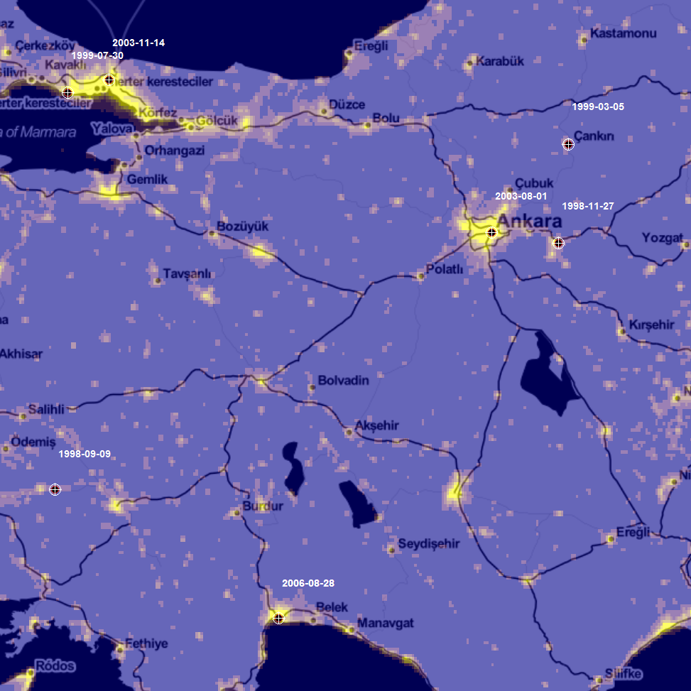

Now we know something more about these places than we did not before. This information will become part of our measure for “connectedness”. But there is much more, like travel distance to the next biggest city, measured by the time needed to get there.

**Road Access**

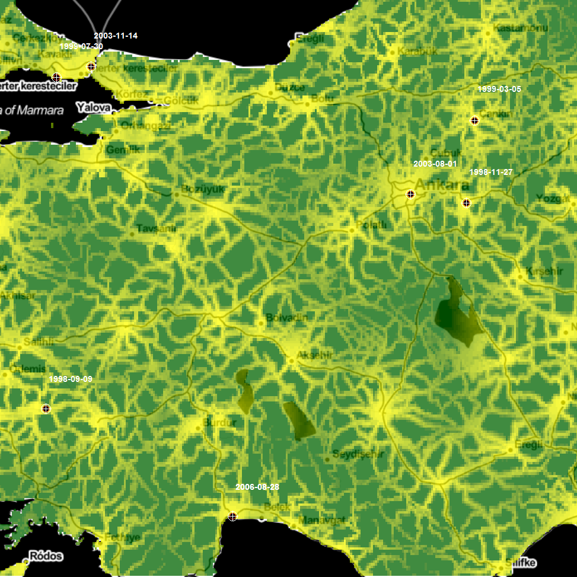

**Distance to Coast**

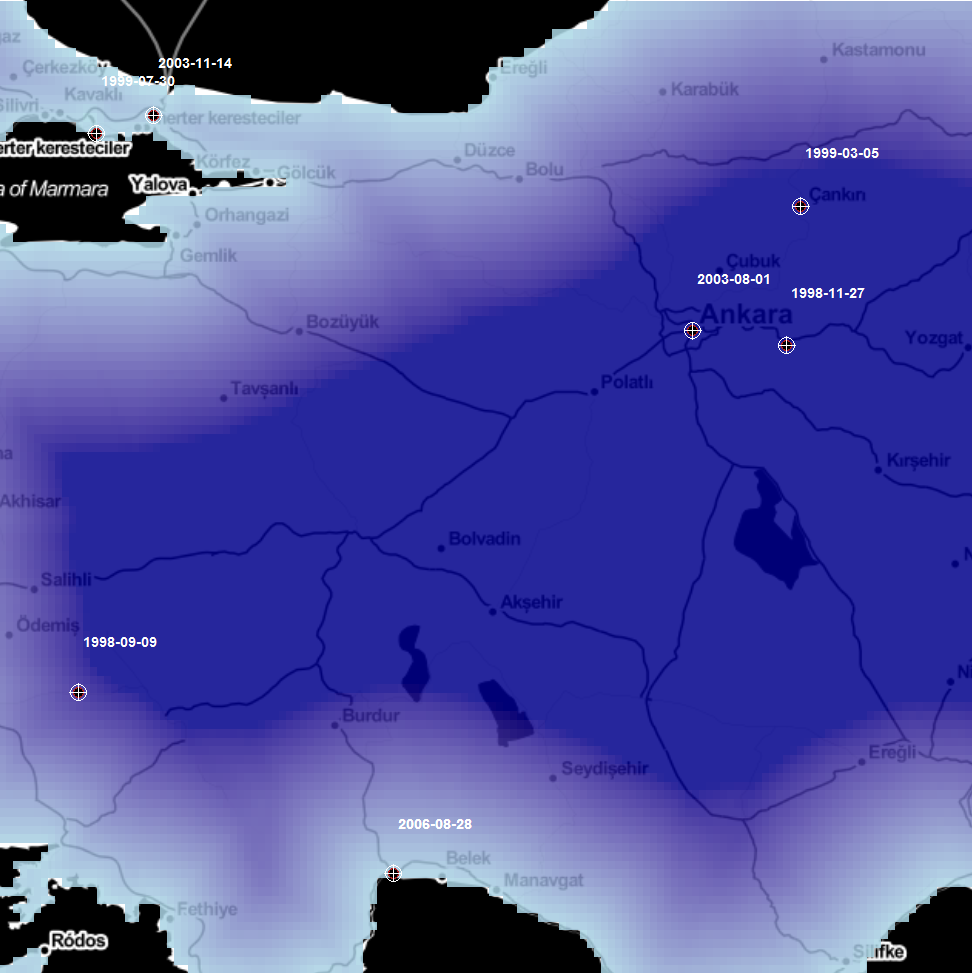

**Population Density**

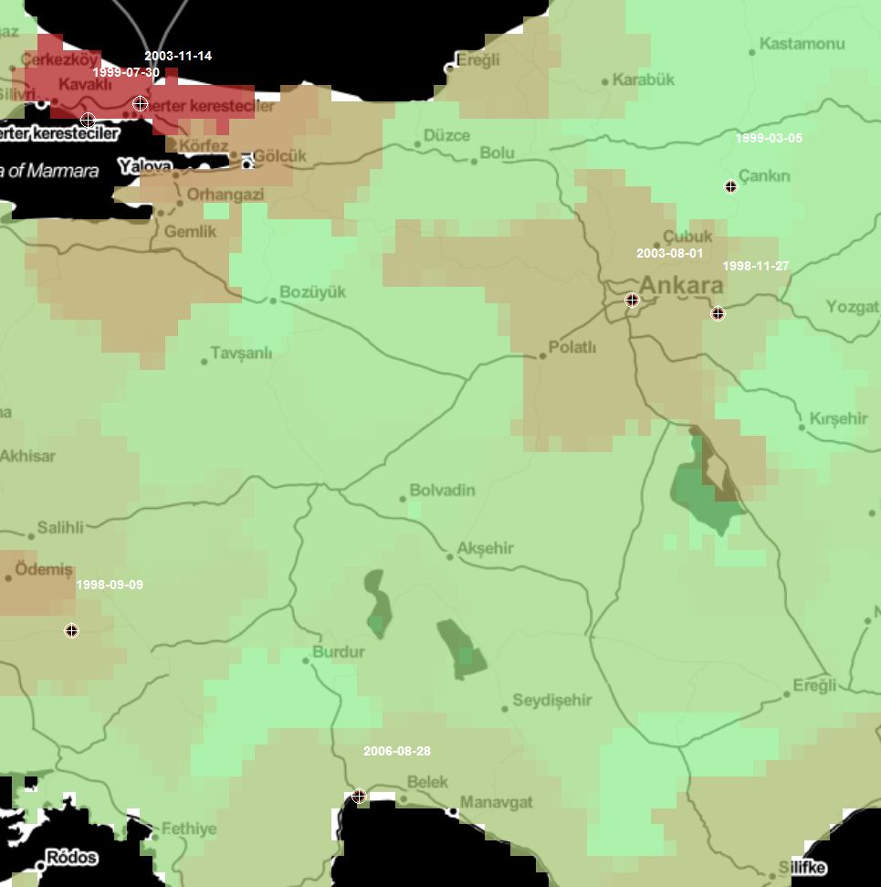

## Analysis

Collecting all this information was necessary to put together variables that represent the concepts of e.g. “crowdedness” or “littoralnes”. We then feed all of this data into a statistical model. The outcome is this regression table, which tells us how much our independent variables (like urbanization) influence the dependent variables, meaning the characteristics of the violent extremists’ targets.

**Linear Regression on Panel Data - Country Fixed Effects - 1998-2013**

|  | Target Variables (Relative to Country Maximum %) |  |  |  |  |
| --- | --- | --- | --- | --- | --- |
|  | Urban | Crowded | Connected | Littoral | All Combined |
| Time (Year) | -0.036 | 0.068 | -0.064 | -0.604 | -0.159 |
|  | (0.602) | (0.418) | (0.687) | (0.396) | (0.444) |
| Urban Population Share (% of total) | -1.501*** | -1.042*** | -1.503*** | 0.056 | -0.997*** |
|  | (0.501) | (0.347) | (0.571) | (0.329) | (0.369) |
| Urban Population Share*Time | 0.005 | 0.002 | 0.008 | 0.008 | 0.006 |
|  | (0.008) | (0.006) | (0.009) | (0.005) | (0.006) |
| Population’s Coastal Distance (% of max) | -0.156 | -0.067 | -0.242 | -0.387*** | -0.213* |
|  | (0.174) | (0.121) | (0.198) | (0.114) | (0.128) |
| Population’s Coastal Distance*Time | -0.001 | -0.001 | -0.002 | -0.0002 | -0.001 |
|  | (0.001) | (0.001) | (0.001) | (0.001) | (0.001) |
| Observations | 608 | 608 | 608 | 608 | 608 |
| R<sup>2</sup> | 0.868 | 0.886 | 0.882 | 0.978 | 0.939 |
| Adjusted R<sup>2</sup> | 0.855 | 0.875 | 0.870 | 0.975 | 0.933 |
| Residual Std. Error (df = 553) | 17.886 | 12.397 | 20.396 | 11.759 | 13.178 |
| F Statistic (df = 55; 553) | 66.080*** | 78.272*** | 75.271*** | 439.708*** | 155.557*** |
| *Note:* | p<0.1; p<0.05; p<0.01 |  |  |  |  |
|  | Observation are yearly country means |  |  |  |  |

[output not shown]

**to be continued…**

We hope you like this website. Feel free to shoot us a message, ask for more regression tables or our data if you like!

Sascha - saschust@syr.edu Lukas - lbretzin@syr.edu Cameron - ccreed@syr.edu

*Atlantis Transatlantic Degree Program in International Security*

References

Kilcullen, David. 2013. *Out of the Mountains: the Coming Age of the Urban Guerrilla*. Oxford University Press.

START. 2013. *Global Terrorism Database $GTD$*. Maryland: National Consortium for the Study of Terrorism; Responses to Terrorism. http://www.start.umd.edu/gtd.